# Net_Results

Lihe Liu

3/22/2020

## Network

1. After filteration, 7034 genes were kept for network modeling (criteria detailed in M&M)

```r
dim(datExpr_control);dim(datExpr_treatment)
```

```
## [1]    9 7034
```

```
## [1]   10 7034
```

2. Soft thresholds: raise (abosolute) Pearson correlation to a power thus R square reachs 0.8, 24 was selected. Intuitively, mean connectivity is decreasing. here we prioritized high correlation and ‘compress’ the net to high density.

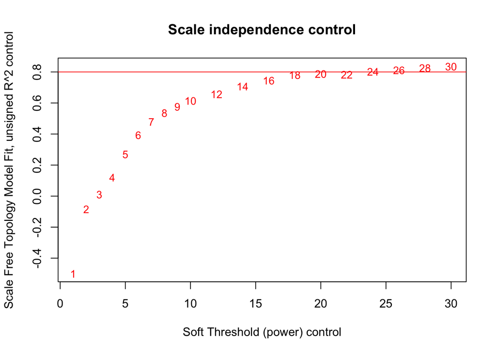

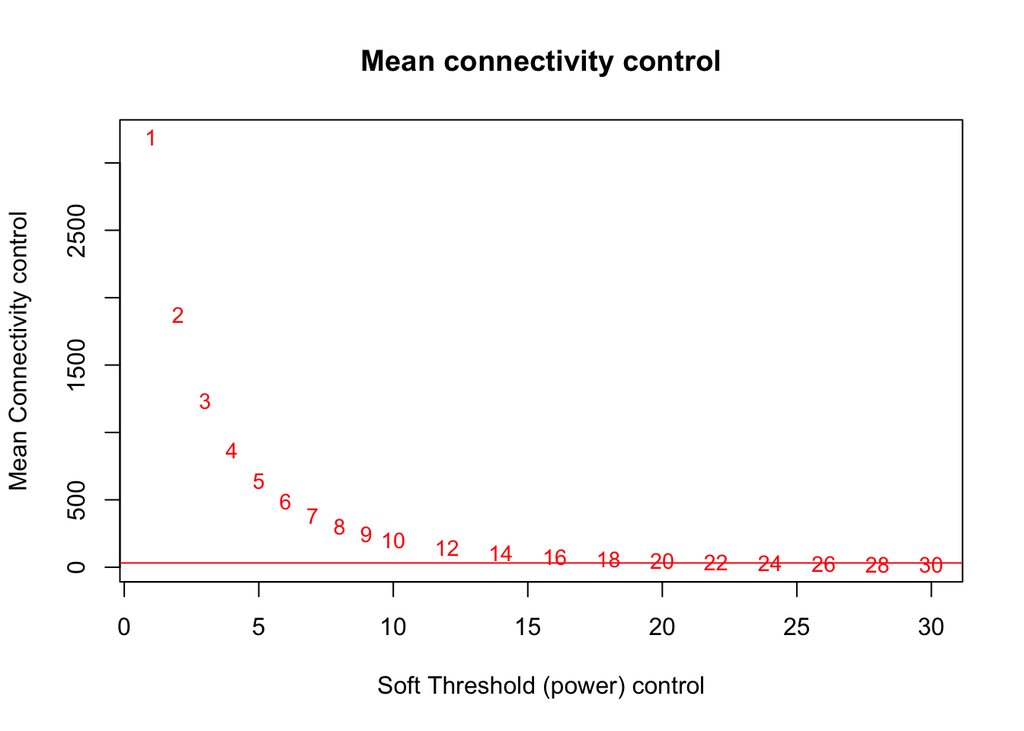

3. Further, TOM was calculated and 1-TOM was used for clustering.

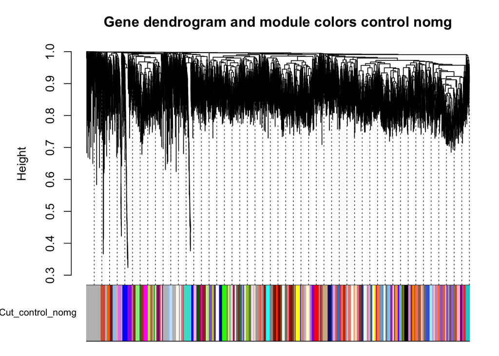

4. Modules with high correlated module eigen vector (r > 0.8) will be merged.

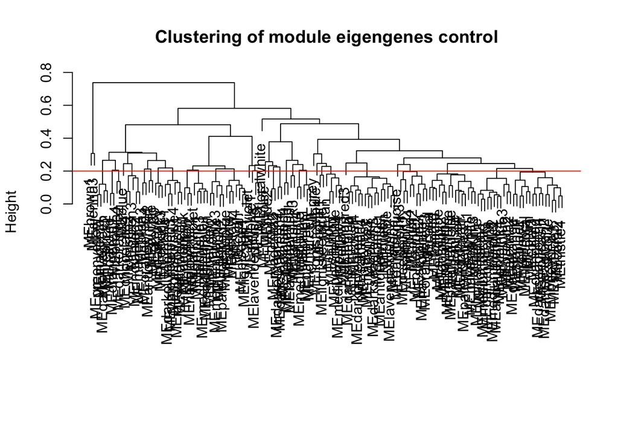

5. now we compare

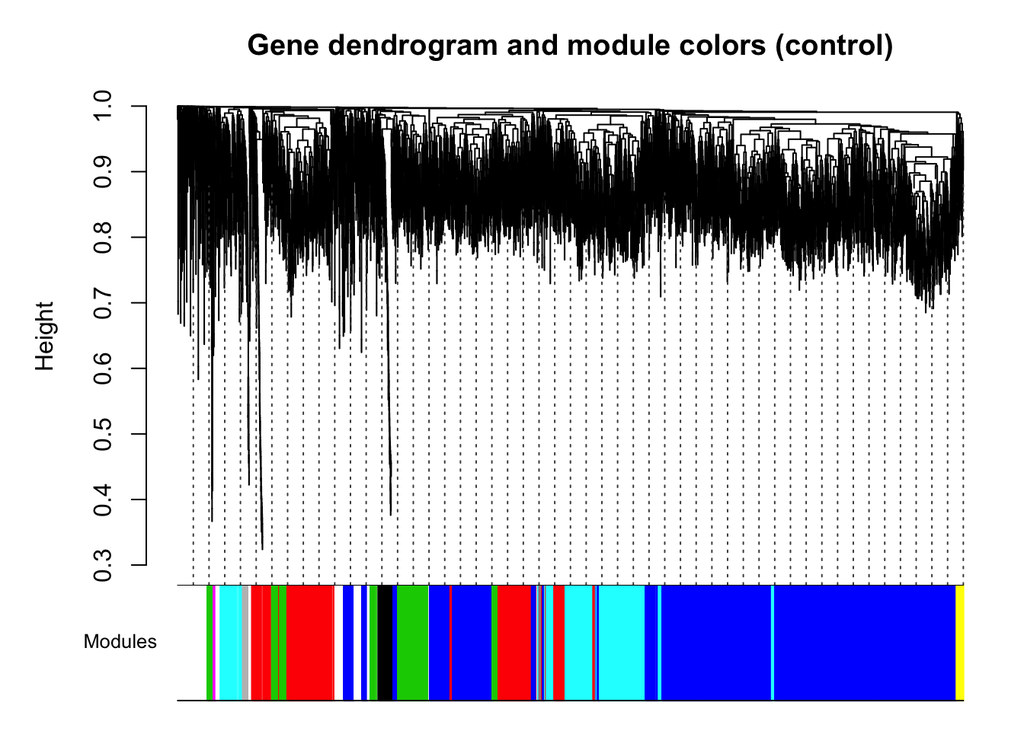

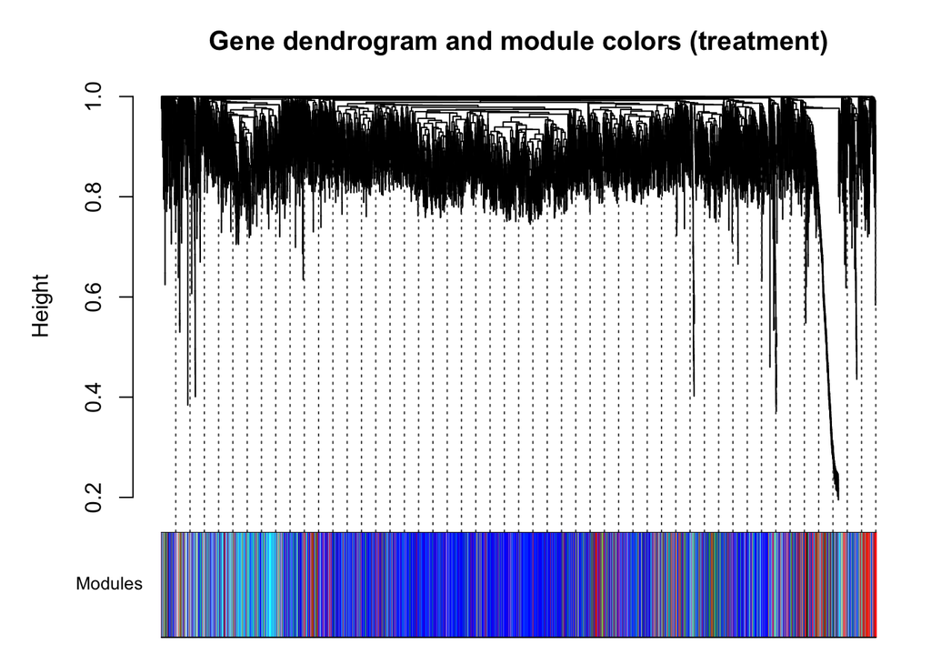

6. Module statistics (with 2000 permutations): 6 unpreserved modules for further investigation

```r
# first 4 columns are summarizing stats (but we might want to report all)
MP_Stats_final
```

```
##        Row.names moduleSize medianRank.pres Zsummary.pres Zdensity.pres
## 1  antiquewhite2        985              13    -1.6829944    -2.5954346
## 2           blue         97               3     8.1778462    13.8274548
## 3          blue2         41               9     0.4240597     0.3328316
## 4          brown        529               9     2.5732222    -0.2314634
## 5         brown1         23              11    -0.1169131    -0.5542049
## 6         coral1       3440               5    12.4625480    10.7822311
## 7  darkturquoise         61               6     0.9711968     1.1943423
## 8     darkviolet        997               7    12.8912987     3.4996362
## 9    floralwhite         52              10     0.8812654    -0.5362275
## 10    indianred3         32               1     4.9554953     9.2154219
## 11       sienna3         56               9     2.4670397    -0.1362557
## 12     turquoise        135               3     9.9166199    13.6205179
## 13        violet         57               8     0.6593350    -0.3376285
##    Zconnectivity.pres Z.propVarExplained.pres Z.meanSignAwareKME.pres
```

[output cut: 41 more lines]

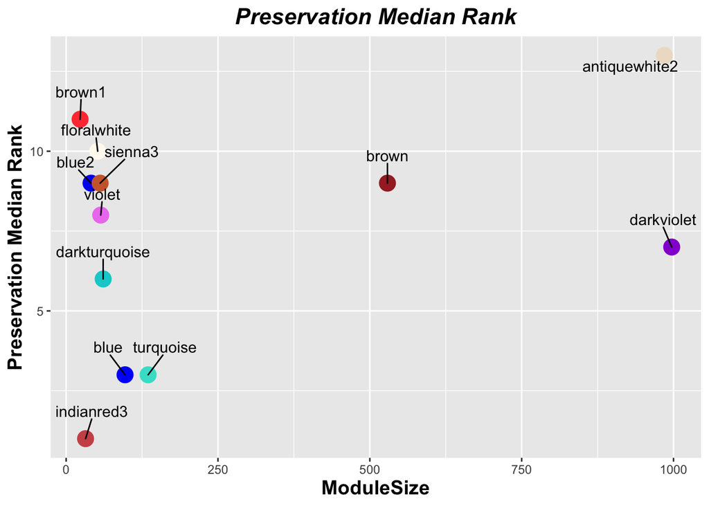

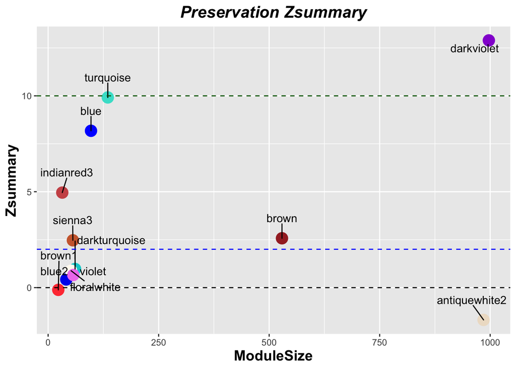

7. Functionaly characterization (enrichment)

```r
# GO, KEGG, Interpro, Reactome, MeSH, MsigDB
# Compressed in another zip
# which kind of plot we need?
```

## DNA Methylation

1. match region:
- 25491 genes has CpG detected (flagging)
- 8817 genes has **signif CpG** detected in all regions (define: 20% methy and qval < 0.1)
- **However**, only **7994** genes were captured in RNA-Seq and **3326** were included in network analysis (**tough loss**, potentially problematic)

```r
Genes_meth_prop %>%
  dplyr::filter(!(Count1 == 0 & Count1 == 0),Gene %in% Gene_all) %>% dim()
```

```
## [1] 7994    8
```

```r
#
Genes_meth_prop %>%
  dplyr::filter(!(Count1 == 0 & Count1 == 0),Gene %in% Gene_net) %>% dim()
```

```
## [1] 3326    8
```

```r
#
head(Total_C_count) # dataset example
```

```
## # A tibble: 6 x 10
##   Gene  `1st_EXON` DOWNSTREAM GENE_BODY INTRON PROMOTER   TSS UPSTREAM Count1_all
##   <chr>      <dbl>      <dbl>     <dbl>  <dbl>    <dbl> <dbl>    <dbl>      <dbl>
## 1 ENSB…          1         29        45    660        7     0       19        706
## 2 ENSB…          0         15         8    130        4     0        4        138
## 3 ENSB…          0          2         5      0        0     0       18          5
## 4 ENSB…          0         36         4    104        9     2        9        108
## 5 ENSB…          9          9        20     97       11     0       10        126
## 6 ENSB…          0          3         6     26        5     1        0         32
## # … with 1 more variable: Count2_all <dbl>
```

2. Question 2: Are genes in unpreserved modules more methylated that those preserved (all represents all methylation information we captured)
- Unfortunatelly, only 414 genes in all unpreserved modules are included, but we can still learn something.

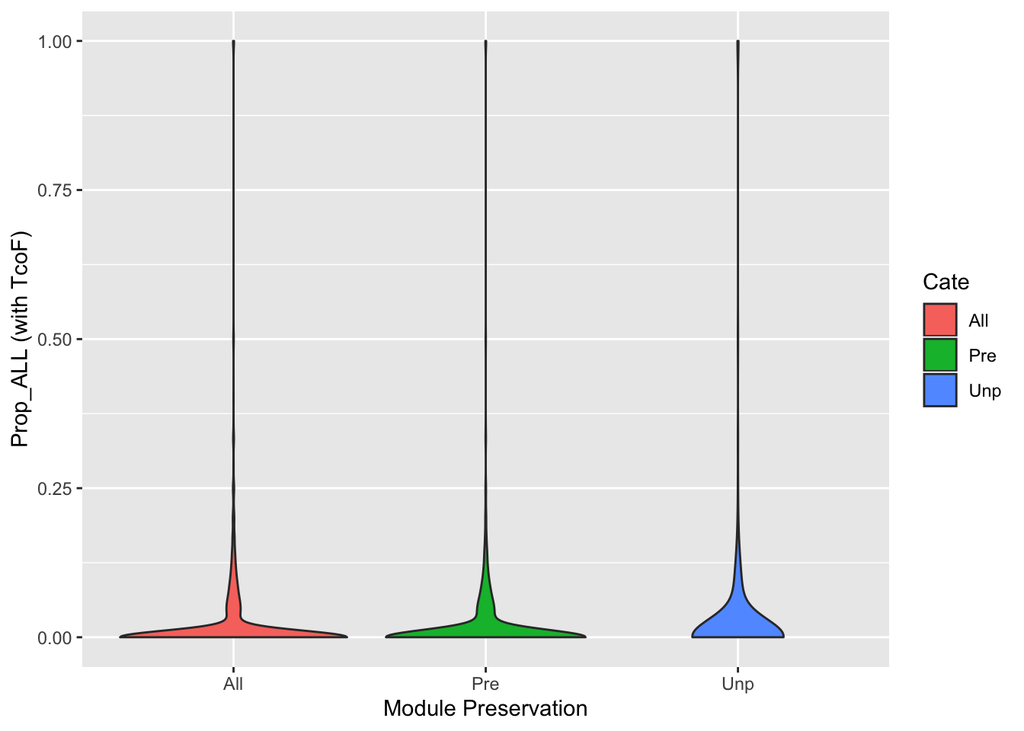

```r
ggplot()+
  geom_violin(data = LargeCate_plot2,
              aes(x = Cate,y =Prop_Prpt,fill=Cate))+
  #geom_flat_violin(position=position_nudge(x=.2)) +
  #geom_violin(alpha =.8,width = .8) +
  #geom_boxplot(outlier.alpha = 0.2,outlier.size = 0.3) +
  xlab("Module Preservation") + ylab("Prop_ALL (with TcoF)")
```

3. Question 2: In a given module, are those genes with high connectivity (hub) get more chances to be methylated?

```r
# show PDF
```

[output not shown]

4. Question 3: Is there any enrichment of the differentially methylated genes? (will explain later in the Hyper G section)

## Transciption Factor Analysis

```r
length(unique(Bta_TF_OverlapMatch$TF_Name))
```

```
## [1] 68
```

1. Are the Methylation status of TFs of each module the same? (Unpreserved > preserved)

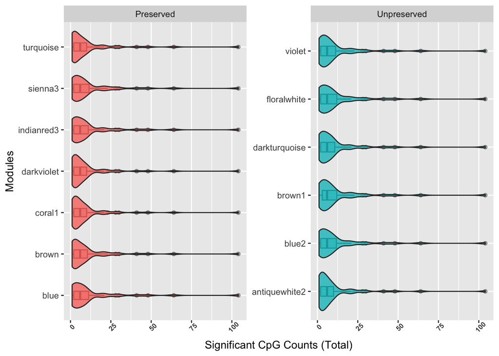

```r
#Overall CpG Counts of TF(TcoF) in every module
ggplot(Bta_TF_OverlapMatch_plot,
       aes(x = Module,
           y=(Count1.x + Count2.x),
           fill=Pres)) +
  geom_boxplot(alpha =.4,width = .2)+
  geom_violin(alpha =.8,width = .8) +
  facet_wrap(~Pres,scales = 'free',
             labeller = labeller(Pres = c(Pre = "Preserved", Unpre = "Unpreserved")))+
  theme(axis.text.x = element_text(face = "bold",size = 7,angle = 45),
        legend.position = "none")+
  coord_flip()+
  xlab("Modules") + ylab("Significant CpG Counts (Total)")
```

2. Are the Methylation status of TFs responsible for unpreserved/preserved modules the same? (Unpreserved > preserved) (All represents all bovine TFs methylation captured)

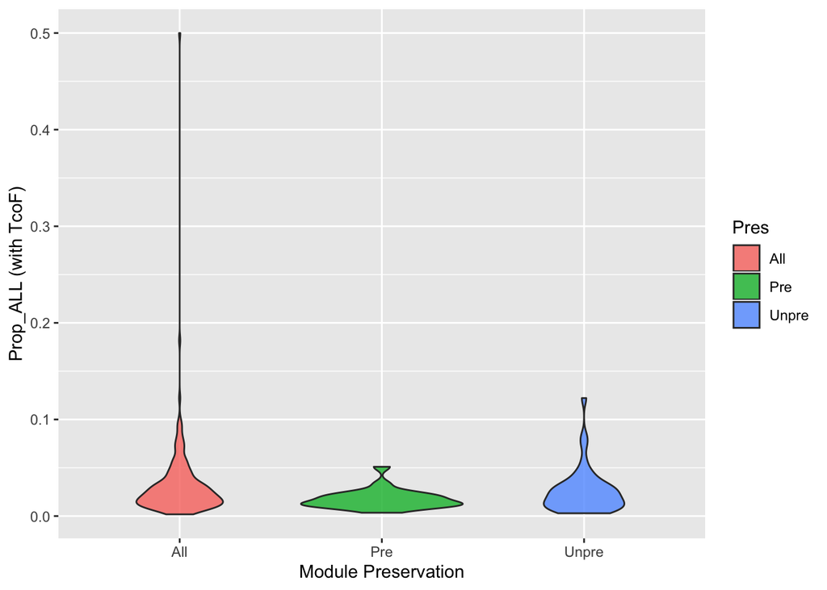

```r
ggplot(LargeCate_plot1,
       aes(x = Pres,y =Prop_All_Final,fill=Pres))+
  geom_violin(alpha =.8,width = .8) +
  xlab("Module Preservation") + ylab("Prop_ALL (with TcoF)")
```

## Hyper G test

we defined some gene list in the process: 1. Top 20% Differentially co-expressed genes: length-wise distance of adjacency vector (784 genes)  
2. Differentially methylated genes: (261) - Define 3. TF targeting many genes in any of the modules (say more than 20%) (225)

```r
# Diff meth
Module_Overrep
```

```
##               V1  V2 V3          V4
## 1           blue Not  1 0.712672239
## 2          brown Not  8 0.362113472
## 3         coral1 Not 56 0.028784519
## 4     darkviolet Not 12 0.622082458
## 5     indianred3 Not  1 0.336858281
## 6        sienna3 Not  0 1.000000000
## 7      turquoise Not  4 0.094387586
## 8  antiquewhite2 Sig 13 0.488998495
## 9          blue2 Sig  0 1.000000000
## 10        brown1 Sig  0 1.000000000
## 11 darkturquoise Sig  0 1.000000000
## 12   floralwhite Sig  1 0.487176903
## 13        violet Sig  0 1.000000000
## 14          Grey Not 14 0.008224866
```

```r
# Diff TF
Module_Overrep_TF
```

```
##               V1  V2  V3           V4
## 1  antiquewhite2 Sig  17 8.637221e-01
## 2          blue2 Sig   2 2.229494e-01
## 3         brown1 Sig   3 1.298912e-02
## 4  darkturquoise Sig   2 3.825372e-01
## 5    floralwhite Sig   0 1.000000e+00
## 6         violet Sig   3 1.262447e-01
## 7           blue Not   1 8.813075e-01
## 8          brown Not   4 9.970584e-01
## 9         coral1 Not 111 5.816847e-06
## 10    darkviolet Not  25 2.539996e-01
## 11    indianred3 Not   1 5.043834e-01
## 12       sienna3 Not   1 7.074578e-01
## 13     turquoise Not   7 2.793443e-02
```

```r
# DCG
Module_Overrep_DCG
```

```
##               V1  V2  V3        V4
## 1  antiquewhite2 Sig  36 0.6388321
## 2          blue2 Sig   2 0.4690031
## 3         brown1 Sig   0 1.0000000
## 4  darkturquoise Sig   3 0.4151251
## 5    floralwhite Sig   4 0.1373721
## 6         violet Sig   1 0.8922685
## 7           blue Not   2 0.8903329
## 8          brown Not  13 0.9693263
## 9         coral1 Not 673 0.0000000
## 10    darkviolet Not  31 0.9059847
## 11    indianred3 Not   6 0.0011930
## 12       sienna3 Not   0 1.0000000
## 13     turquoise Not   8 0.1468178
```

## Thoughts

1. lost of info is a problem, every layer is eating data
2. last part does not really make sense
3. Cant’s explain myself? not convincing?
4. what else we could do?